# Minimum Indonesia Model with Boxcars and Gear

Ernesto Carrella

January 4, 2018

Take one more time the 1 species boxcar model we described [here](http://carrknight.github.io/poseidon/boxcar_indonesia.html). We made some silly assumption on location there to give a way for agents to fish older fish if they so choose.

Here we remove that assumption and instead assume that fish is homogeneously distributed in terms of age. Agents need to change gear to avoid juveniles.

## Continuous

Imagine that fishers are able, by changing gear or strategy or way of fishing, to modify both the `Intercept` and `Slope` parameter of their selectivity curve. Let’s assume however that agents aren’t sure about how each change in their fishing ways actually modify selectivity so that they still need to proceed by trial and error.

Agents have a probability of 20% each two months to modify their fishing strategy (mathematically by shocking `Intercept` and `Slope` by $\sim U(.8,1.2)$). If after two months the profits have increased, they keep fishing in the new way. Otherwise they go back to the old ways. Agents also have a 60% change of looking at what their “friends” are doing; if their friends are making more money they copy their fishing strategy.

If landed fish is paid 10$ a kg regardless of size and we track average selectivity parameters within the population, running the model 20 times gives us the following dynamic (each line is the average parameter within a simulation):

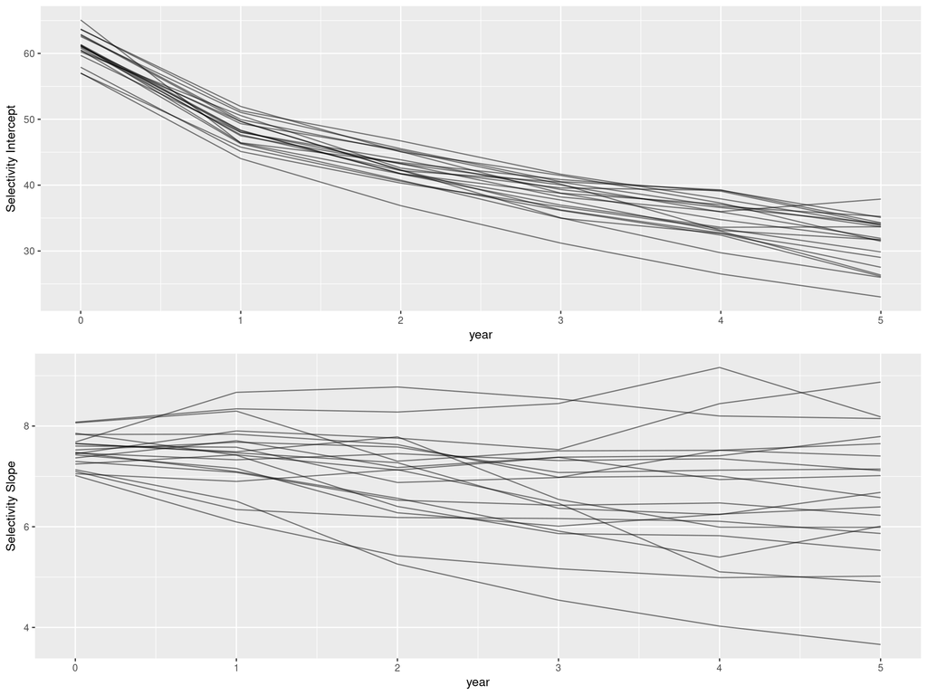

That is, the incentive is to shift the intercept down over time (slope is more random walk). This makes sense if we look at the selectivity curve itself:

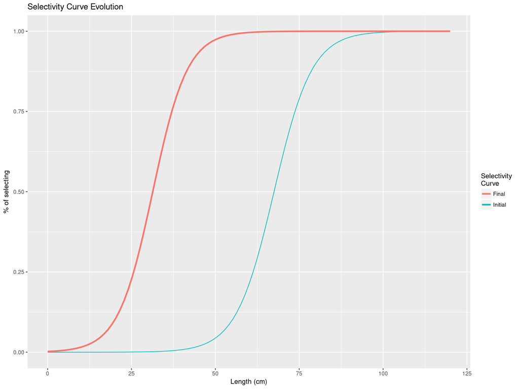

Selectivity curves shifts to the left: fishers switch to strategies that catch more juveniles as well as more matures. This is obvious: the more you catch the better.

### Adding Fines

Now let’s see what happens if we ban landing below optimum size (66cm) or if we fine them (30$ per kg):

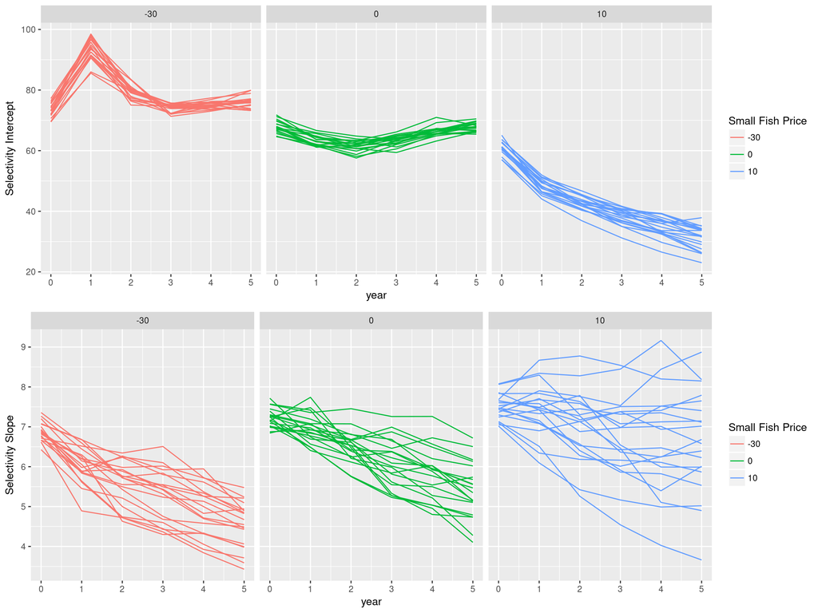

When there is a fine the intercept increases and the slope drops. When there is a ban the intercept is about constant but the slope decreases. We can check what happens to the selectivity curve (dashed line is the 66cm mark).

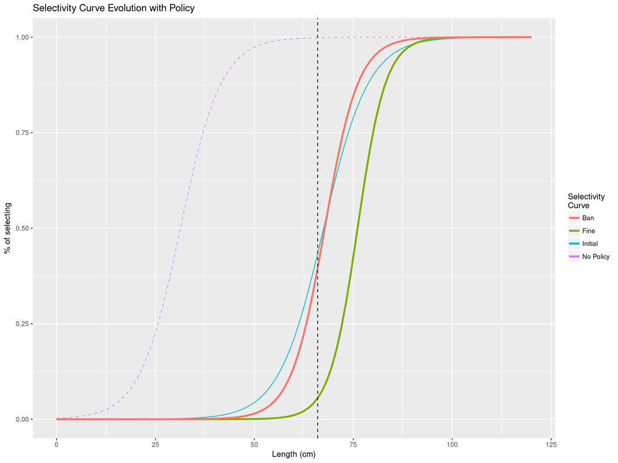

In both cases the selectivity curve shifted to the right (making catching small fish less likely) unlike the no-policy scenario where the curve shifted to the far left. The fines were obviously a stronger incentive as the shift is more pronounced.

Finally we can look at the overall effects in terms of fish caught (that is, what eventually happens when the selectivity curve meets the biomass available)

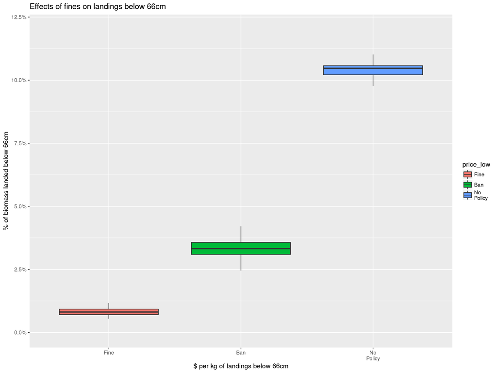

Compared to the [previous demo](http://carrknight.github.io/poseidon/boxcar_indonesia.html) where one could only avoid small fish by changing where to fish, we can achieve stronger results with gear selection (both for ban and fines) while the no-policy equilibrium is worse as the amount of small landings is higher.

### Subsidies

Unlike the locational model, the subsidies (pay 30$ a kg for mature) are not very effective without a backing fine. They do stop the move toward unselective gear but do not have the same effect as a ban or a fine would.

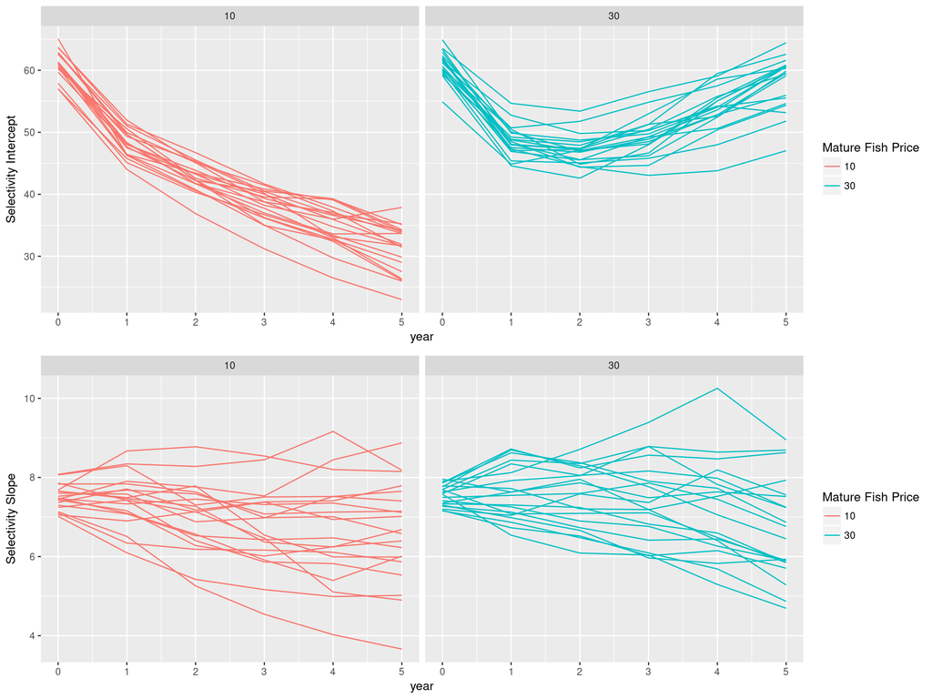

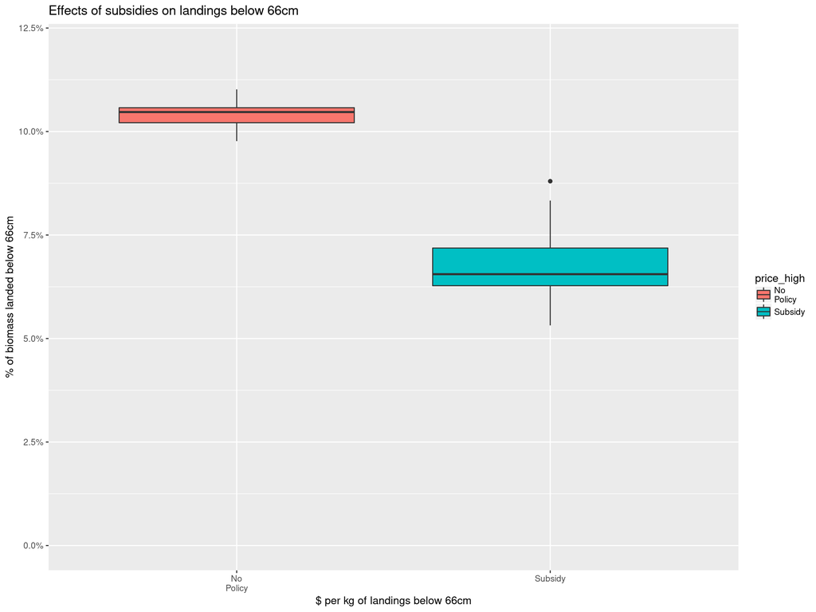

## Discrete

Imagine now that agents can’t change gear over a continuum of `Intercept` and `Slope` parameters, rather they can only pick one of three choices:

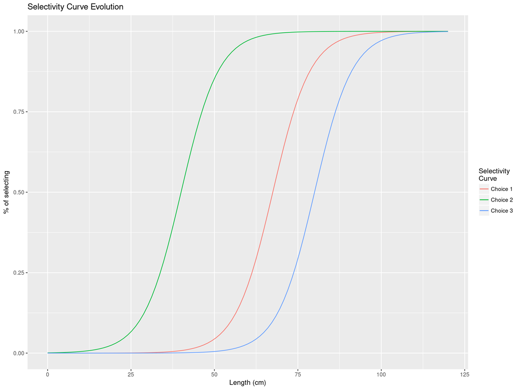

Which correspond to choosing at `Intercept` at either 40, 67 or 80 (while `Slope` stays constant). Agents again proceed by bi-monthly trial and error with 20% exploration and 60% imitation rate. Initially everybody starts with choice 1 (`Intercept` at 67).

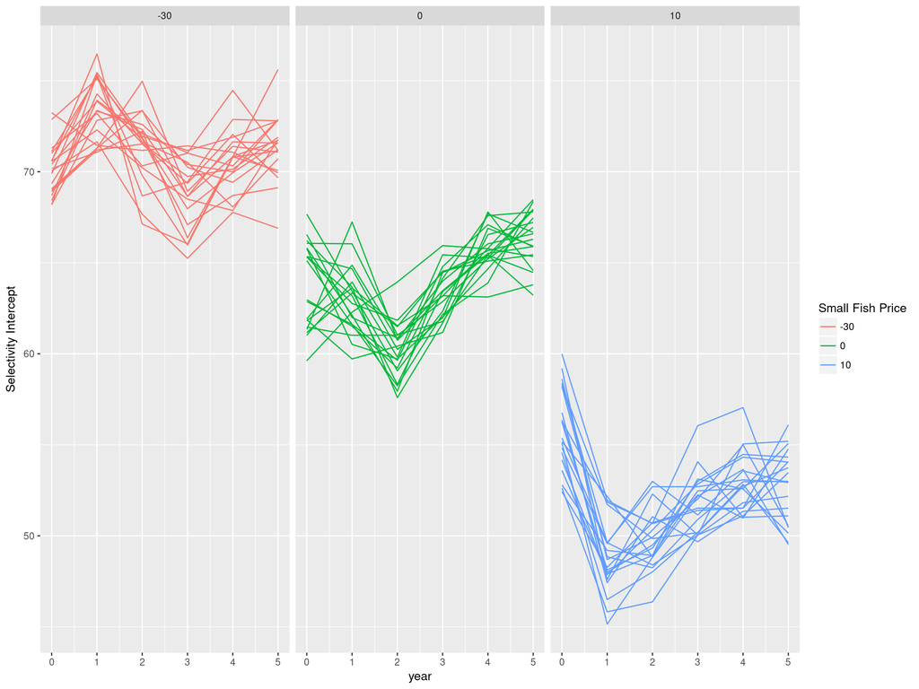

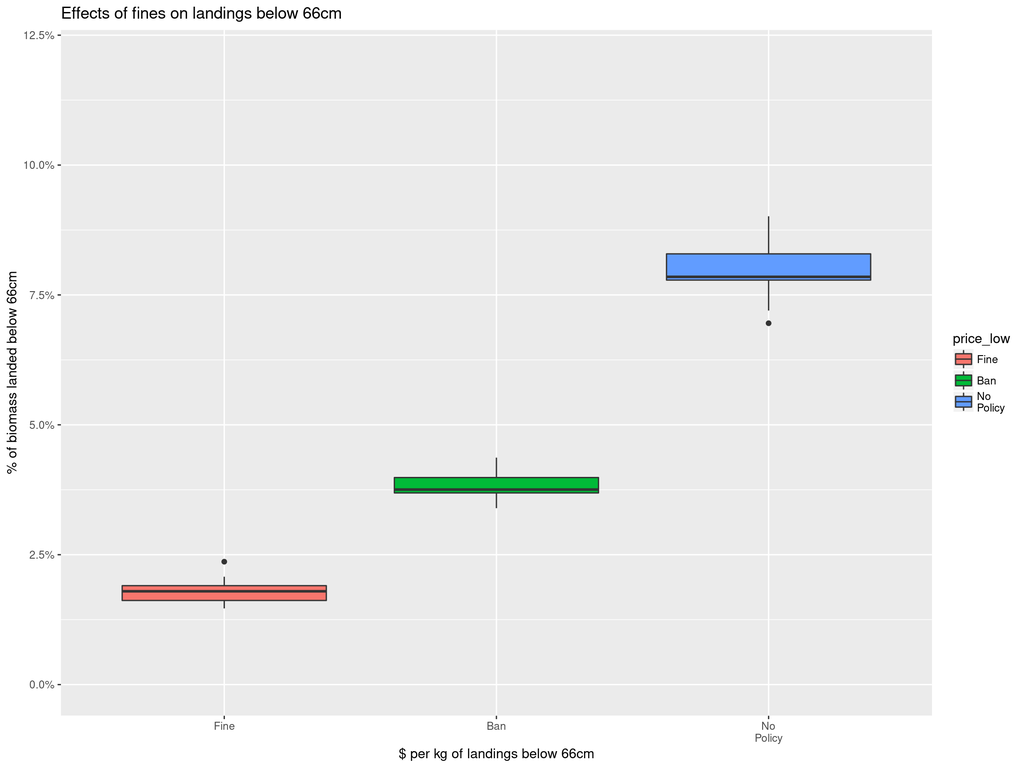

### Subsidies

Again, subsidies do in generally less well that fine or banning.

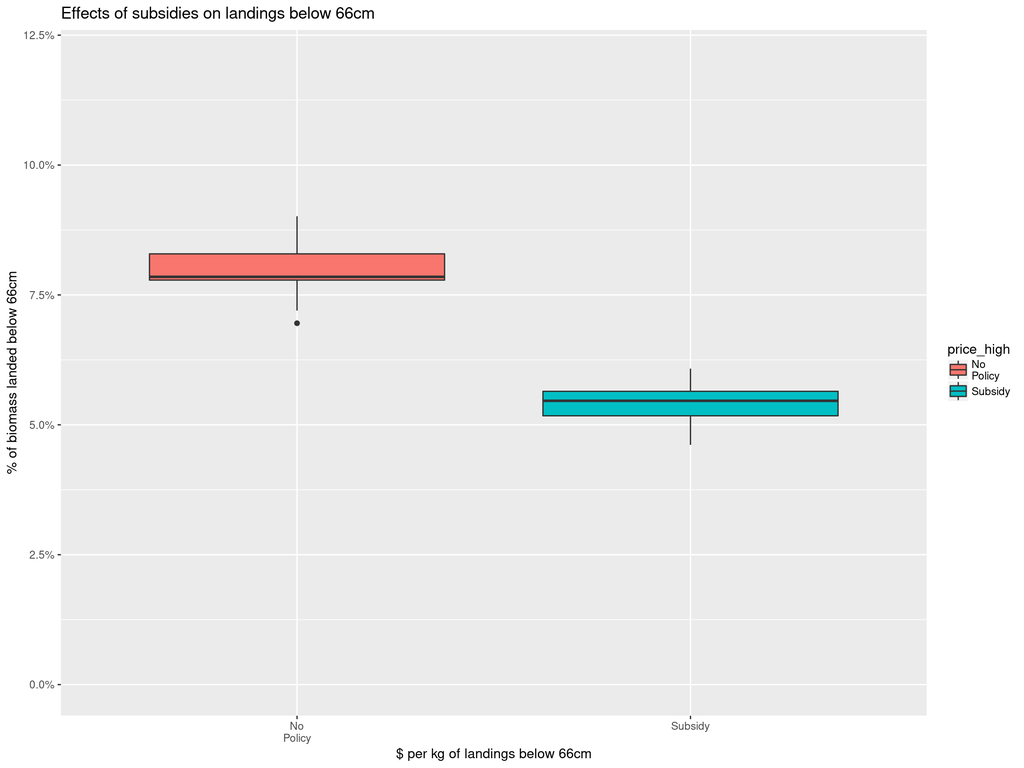